# 2D-s ábrák

Legtöbbször a legjobb ábrák a legegyszerűbb ábrák! Az alábbiakban áttekintünk néhány egyszerű ábrakészítési módot, amelyek segíségével a leggyakrabban előforduló ábrázolási problémáinkat orvosolhatjuk. Fontos megjegyezni, hogy ábrát a `matplotlib` segítségével több hasonló módon is elő lehet állítani. Az alábbiakban törekedünk a lehető legegyszerűbb módszer bemutatására. Fontos azt is megjegyezni, hogy az alábbi példákban előforduló függvényopciók (kulcsszavas argumentumok) lehetséges értékeinek csak egy szűk halmazára térünk ki. A megfelelő paraméterek lehetséges értékei után vagy a [matplotlib mintapáldái](http://matplotlib.org/gallery.html#) vagy a megfelelő függvények, pl. `plot`,`hist`,`pcolor`, `contour` és `contourf` docstring-jében érdemes kutatni!

```python
#a már megszokott betöltési parancs
%pylab inline
```

## Egyszerű függvény és adat ábrázolás

Sok esetben a feladat egy ismert adathalmaz, netán egy analitikus függvény ábrázolása. Ha analitikus fügvénnyel van dolgunk, akkor az ábrázoláshoz először legyártunk kiértékelési pontokat, ezután ezekben a pontokban kiértékeljük az adott függvényt. Az alábbi példában a $\sin(x)$ függvényt fogjuk kiértékelni a $[-\pi,\pi]$ intervallumban 25 pontban.

```python
x=linspace(-pi,pi,25);
y=sin(x);
```

Az ábrázolás (ahogy azt már korábban is láttuk) a `plot` paranccsal történik.

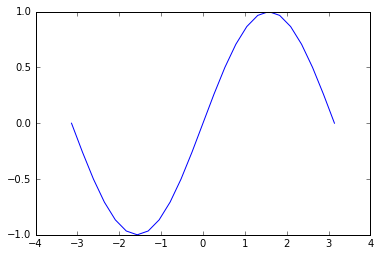

```python
plot(x,y)
```

Vizsgáljunk meg néhány kulcsszavas argumentumot, amely segítségével a `plot` parancs kimenetelét tudjuk változtatni. A `color` kulcsszó az ábrázolt adat színeit változtatja meg. [Ez](http://matplotlib.org/_images/named_colors.png) az ábra tartalmazza a `matpotlib`-ben néven nevezett színek nevét. Változtassuk meg a fenti ábrában a görbe színét pirosra!

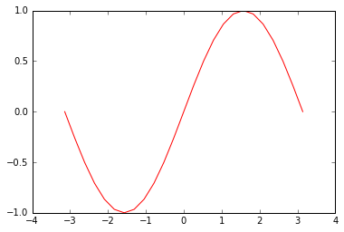

```python
plot(x,sin(x),color='red')
```

A `linewidth` kulcsszó segítségével a vonalszélességen változtathatunk.

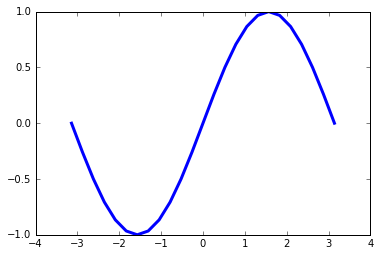

```python
plot(x,sin(x),linewidth=3)
```

A `linestyle` kulcscszó a vonalstílust állítja be. Ez lehet megnevezett kulcsszó (mint az alábbi példában) vagy [szimbólum](http://matplotlib.org/_images/line_styles_reference.png) is.

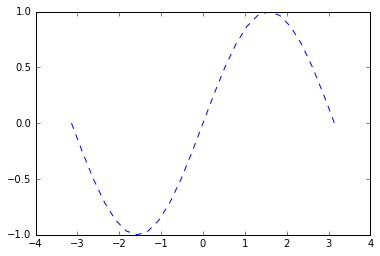

```python
plot(x,sin(x),linestyle='dashed') # szaggatott vonal (angolul: dashed line)
```

Ha üres stringet adunk vonalstílusnak, és a `marker` kulcsszót használjuk, akkor az ábrán csak pontok jelennek meg. Így például ábrázolhatunk olyan adatokat, amik nincsenek szépen sorbarendezve.

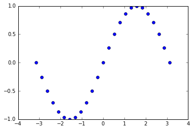

```python
plot(x,sin(x),linestyle='',marker='o')
```

Ha a `linestyle` és a `marker` kulcsszavakat egyszerre alkalmazzuk, akkor a markereket a kért vonalstílussal köti össze a `matplotlib`.

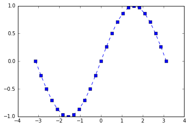

```python
plot(x,sin(x),linestyle='dashed',marker='s')
```

Természetesen ahogy már megszoktuk, kulcsszavas argumentumokból egyszerre többet is beadhatunk (vajon mit jelenthetnek azok a kulcsszók, amiről eddig nem volt szó?):

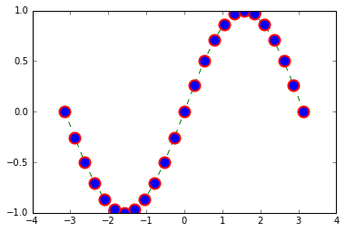

```python
jellemzok=dict(color='green', linestyle='dashed', marker='o', markerfacecolor='blue',
               markeredgecolor='red',markeredgewidth=2, markersize=12 )

plot(x, sin(x), **jellemzok)
```

Az ábra tengelyeinek tartományát az `xlim()`, illetve `ylim()` függvények segítségével tudjuk beállítani, melyeket a `plot` függvény után hívunk meg:

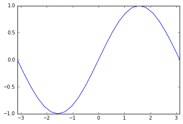

```python
plot(x,sin(x))
xlim(-pi,pi);
```

A plot függvény számos más kulcsszavas argumentummal rendelkezik. A docstring-jében mindezek jól le vannak dokumentálva!

```python
?plot
```

Ha két (vagy több) `plot` parancsot adunk ki egymás után, akkor az ábrán egyszerre két (vagy több) függvény is megjelenik.

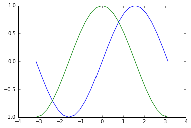

```python
plot(x,sin(x))
plot(x,cos(x))
```

Speciális esete ennek az, amikor az egyik `plot` csak egyetlen pontot tartalmaz. Ezzel a módszerrel jelölhetünk érdekes pontokat a függvény görbéjén.

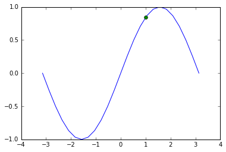

```python
plot(x,sin(x))
plot(1,sin(1),'o')
```

Ha több függvényt ábrázolunk, akkor a `label` kulcsszó és a `legend()` függvény segítségével tudjuk egyszerűen jelölni, hogy melyik görbe melyik függvényt ábrázolja.

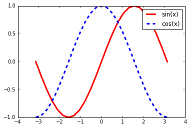

```python
plot(x,sin(x),label='sin(x)',color='red',linestyle='-',linewidth=3)
plot(x,cos(x),label='cos(x)',color='blue',linestyle='--',linewidth=3)
legend()
```

Az `xlabel()` és az `ylabel()` függvények segítségével tengelyfeliratokat készíthetünk.

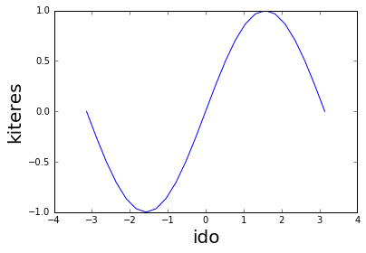

```python
plot(x,sin(x))
xlabel(r'ido',fontsize=20)
ylabel('kiteres',fontsize=20)
```

Az `xticks()` és `yticks()` függvények a a tengelybeosztások formázásáért felelősek. Segítségükkel tudjuk a beosztásokat saját igényeink szerint beállítani. Ezen függvények dockstringjeit is érdemes megvizsgálni!

[output not shown]

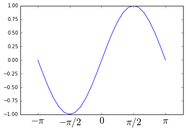

```python
plot(x,sin(x))
xticks([-pi,-pi/2,0,pi/2,pi],[r'$-\pi$',r'$-\pi/2$',r'$0$',r'$\pi/2$',r'$\pi$'],fontsize=20);
yticks(linspace(-1,1,9));
#Vajon mi válltozott a fenti ábrához képest ?
```

Végül nézzünk meg egy példát, amely a fent tanult trükköket egyszerre alkalmazva egy publikációs minőségű ábrát készít.

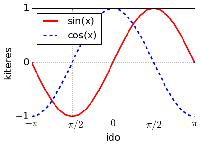

```python
plot(x,sin(x),label='sin(x)',color='red',linestyle='-',linewidth=3)
plot(x,cos(x),label='cos(x)',color='blue',linestyle='--',linewidth=3)
xticks([-pi,-pi/2,0,pi/2,pi],[r'$-\pi$',r'$-\pi/2$',r'$0$',r'$\pi/2$',r'$\pi$'],fontsize=20);
yticks(linspace(-1,1,3),fontsize=20);
xlabel('ido',fontsize=20)
ylabel('kiteres',fontsize=20)
legend(loc='upper left',fontsize=20)
xlim(-pi,pi)
grid(True) #Vajon ez a függvény mit csinál ?
```

Fontos megjegyezni, hogy a vonal- és pontábrázolások kulcsszavas paraméterezését sok másik függvény is megörökölte. Így például 3D-s ábra készítésnél is hasonlóan használhatóak mint itt. Továbbá a tengelyfeliratozás és -beosztás kezelése is hasonlóan általánosabban használható, nem csak a `plot()` parancssal egyetemben!

## Mérési adatok ábrázolása hibával-errorbar

Láttuk, hogy a plot függvény segítségével akár mérési adatpontokat is tudunk ábrázolni. Sokszor azonban a mérések során a mérési hiba is rendelkezésünkre áll! Vizsgáljunk meg erre egy példát! Az alábbiakban a történelmi napfoltadatok ábrázolásán keresztül igazi mérési adatokat fogunk ábrázolni. Az adatok a `data` könyvtárban található `SN_m_tot_V2.0.txt` file-ban vannak. Ahhoz hogy az adatok a rendelkezésünkre álljanak, először be kell tölteni a file tartalmát. Ezt legegyszerűbben a `numpy` modul `loadtxt` függvénye segítségével tehetjük meg. Ez a függvény egyszerűen strukturált adatfileokat olvas be egy `array`-be.

```python
dat=loadtxt('data/SN_m_tot_V2.0.txt'); # a napfolt adatok betöltése.
```

A fenti parancs tehát a `dat` tömbbe beolvasta a file-ban található adatokat. A file 3. oszlopa tartalmazza a megfigyelés idejét években mérve, a 4. oszlop pedig a napfoltok számát. Ábrázoljuk az utolsó 100 pontot az adatfile-ból:

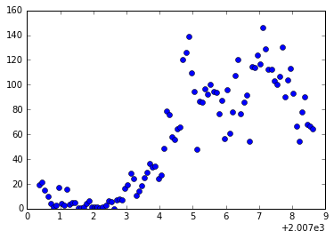

```python
plot(dat[-100:,2],dat[-100:,3],linestyle='',marker='o')
```

Az 5. oszlop viszont a megfigyelések statisztikus hibáit tartalmazza. Ha a mérési pontokat és a hibát egy ábrán szeretnénk látni, akkor ezt az `errorbar()` függvény segítségével megtehetjük.

```
<Container object of 3 artists>
```

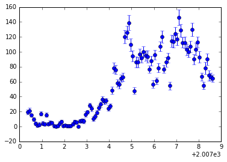

```python
errorbar(dat[-100:,2],dat[-100:,3],dat[-100:,4],linestyle='',marker='o')
```

Az `errorbar()` függvény tehát három bemenő oszlopot vár, amelyekből az első kettő a mérési pontok, illetve a mért értékek, a harmadik pedig a hiba. Ezeken felül, hasonlóan a `plot()`-hoz kulcsszavakkal vezérelhetjük a megjelenést. Az alábbi példa illusztrál néhány kulcsszót.

```
<Container object of 3 artists>
```

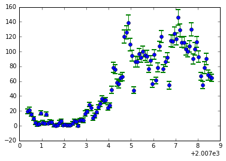

```python
jellemzok=dict(linestyle='',marker='o',ecolor='green',capsize=4,capthick=2)
errorbar(dat[-100:,2],dat[-100:,3],dat[-100:,4],**jellemzok)
```

További opciókról a docstringben kaphatunk némi felvilágosítást:

```python
?errorbar
```

Természetesen két különféle ábrázolást is lehet egy képen megjeleníteni! Az alábbi példában egy `plot()` és egy `errorbar()` függvényt kombinálunk.

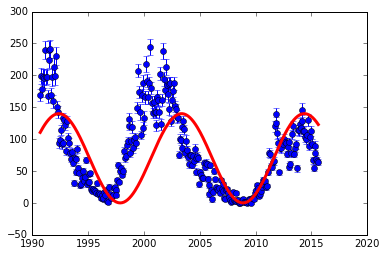

```python
errorbar(dat[-300:,2],dat[-300:,3],dat[-300:,4],linestyle='',marker='o')
plot(dat[-300:,2],70*cos(2*pi/11*dat[-300:,2]-pi*0.25)+70,color='red',linewidth=3)
```

## Hisztogramok

A [hisztogramok](https://hu.wikipedia.org/wiki/Hisztogram) a statisztikai elemzések fontos eszközei. A múlt órán már láttunk pár példát hisztogram készítésére a `hist` parancs segítségével. Ismerkedjünk most meg a `hist()` hisztogramgyártó-rutin néhány kulcsszavas argumentumával. Először is gyártsunk néhány véletlen számot!

```python
meres1=randn(10000);
meres2=random.normal(2,0.5,10000);
```

Amint már korábban láttuk, ez a legegyszerűbb módja a hisztogramgyártásnak.

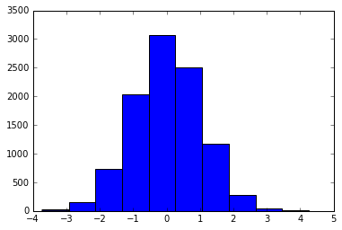

```python
hist(meres1)
```

Ha növelni akarjuk a hisztogram felbontását, akkor azt a `bins` argumentummal tehetjük meg. Ha a `bins` egy számot kap a bemenetre, akkor annyi automatikusan legenerált beosztás szerint gyártódik le a hisztogramm.

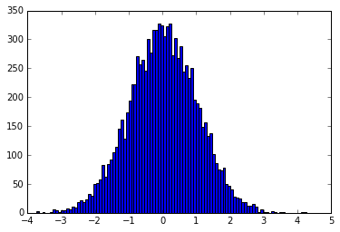

```python
hist(meres1,bins=100);
```

A beosztások széleit önkényesen is megadhatjuk!

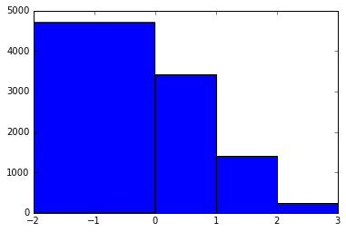

```python
hist(meres1,bins=[-2,0,1,2,3]);
```

Ha oszlopok helyett egy folytonos vonallal szeretnénk elkészíteni a hisztogramot, akkor a `histtype` kulcsszó segít!

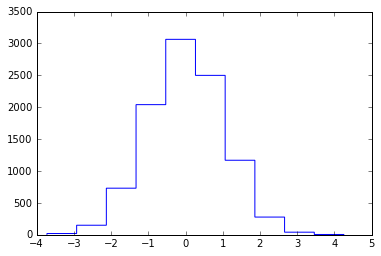

```python
hist(meres1,histtype='step');
```

Természetesen ahogy a plot parancsnál, úgy a hist parancsnál is lehet egyszerre több hisztogramot egy képen ábrázolni.

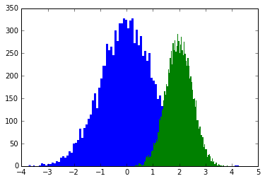

```python
hist(meres1,bins=100,linewidth=0);
hist(meres2,bins=100,linewidth=0);
```

Ha nagyon eltakarná a két eloszlás egymást, akkor az `alpha` kulcsszó segítségével némileg áttetszővé tehetjük őket!

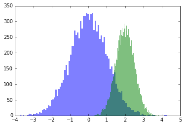

```python
hist(meres1,bins=100,linewidth=0,alpha=0.5);
hist(meres2,bins=100,linewidth=0,alpha=0.5);
```